# Bayesian Estimation Supersedes the T-test (BEST)

### Question 1: What kind of question does BEST solve?

If you work as a data scientist, you have ample opportunities to compare the performance metrics from different groups and interpret how differences will lead to new decision makings. In this lecture, we are going to compare the batting average performance from two MLB players using the Bayesian Estimation Supersedes the T-test (BEST). BEST is a Bayesian model that can be used where you classically would use a two-sample t-test. BEST estimates the difference in means between two groups and yields a probability distribution over the difference.

### Question 2: What are the procedure of implementing BEST and diagnostics that BEST offer?

Using BEST to compare different groups has two main steps. First, we will find number one, proper **prior distributions**, which specify our belief of two player's performance before observing the actual data, number two, choose reasonable likelihood that reflects all relevant information about the data, and find the posterior distribution, which is an updated belief. These procedures can all be done in one model using the probabilistic programming package called PyMC3.

Second, using the posterior distribution, we can compare the differences between two MLB players. We analyze the differences by drawing the posterior distribution plot and the forest plot and see the distribution of **difference of means**, **difference of standard deviations** and finally, **effect size** based on the posterior distribution. This Bayesian type of t-test can not only estimate how different the two groups are, but also how uncertain the differences.

### Question 3: Research Question

There may be various interesting questions to get an answer from one of the most exciting game - American baseball game. Many people are so intrigued in discussing what determines who plays better as a Major League Baseball (MLB) hitter. I listed a few frequently asked questions.

- What percentage of hitting at bat is considered an average MLB player's performance?
- How to test the difference of two MLB hitters to determine who has better hitting performance during a few seasons?

Keep these in mind and let's do some coding!

```python
# From the ESPN.com, we extracted the records for at bats of two famous MLB players - Yuli Gurriel from Houston Astros
# and Vladimir Guerrero Jr. from Toronto Blue Jays. We're interested to see which player had a better at bat performance.

# So let's import the pandas package
import pandas as pd

# and use the pd.read_csv function to bring in the real data from espn for the two top ranked MLB players in 2021.
batting_average = pd.read_csv('assets/mlb_batting_average.csv')

# Let's look at the first few rows of the data
batting_average.head()

# Cool! The data indicates that in year 2016, Yuli Gurriel failed to hit the first 5 bats.
```

|  | Bat Outcome | player | year |
| --- | --- | --- | --- |
| 0 | 0 | Yuli Gurriel | 2016 |
| 1 | 0 | Yuli Gurriel | 2016 |
| 2 | 0 | Yuli Gurriel | 2016 |
| 3 | 0 | Yuli Gurriel | 2016 |
| 4 | 0 | Yuli Gurriel | 2016 |

```python
# Okay, now let's see the last few rows of data using the tail() function.
batting_average.tail()

# You can see that in 2021, Vladimir Guerrero Jr. hit 3 out of the last 5 bats, which is awesome!

print(batting_average['Bat Outcome'].mean())
```

[output not shown]

```
0.2888239116309292
```

### Refined research question:

What we just print out is Batting average (BA). It takes a player's total hits (Bat Outcome == 1) and divides them by total times at bats. The successful hit for Yuli and Vlad accounts for slightly less than 30 percents. An average players in current MLB league hits 27%. Now our data contains batting performance for two players, so let's refine our research. **Given the batting performance of Yuli Gurriel and Vladimir Guerrero Jr., who's batting average is higher? Does any player hit significantly higher proportion of balls in the last few seasons?**

```python
# For the convenience of modeling, we can import the numpy library
import numpy as np

# and save two numpy arrays, one with all records of Yuli
yuli = np.array(batting_average[batting_average['player'] == 'Yuli Gurriel']['Bat Outcome'])
# and another with Vlad.
vlad = np.array(batting_average[batting_average['player'] == "Vladimir Guerrero Jr."]['Bat Outcome'])
```

Now let's estimate the difference in performance between Yuli and Vlad at bat. This time we also time the modeling process to look at the modeling efficiency.

```python
prob = len(batting_average[batting_average['Bat Outcome'] == 1]) / len(batting_average['Bat Outcome'])
np.sqrt(prob * (1 - prob))
```

```
0.4532159084819711
```

```python
%%time
# We need the pymc3 package since it is the toolkit to conduct probabilistic modeling.
# So we import pymc3 as pm, it's shorthand.
import pymc3 as pm


# Prior for group mean. Null hypothesis that the posterior probability distribution of the two MLB players
# are exactly the same, versus the alternative hypothesis that the psoterior prob of the two MLB players
# are different from each other.
# mu_m = batting_average['Bat Outcome'].mean()
# mu_s = batting_average['Bat Outcome'].std() * 2

alpha = len(batting_average[batting_average['Bat Outcome'] == 1])
beta = len(batting_average['Bat Outcome']) - alpha

# # Prior for group standard deviation
# sigma_low = 0.05
# sigma_high = 0.4

# The PyMC3 model is wrapped by the with statement, and let's call the model best_model.
with pm.Model() as best_model:
    # The first step of model specification is creating Beta priors for both players.
    # group 1 - Yuli: We create group1_prob variable with alpha, and beta being the parameters
    group1_prob = pm.Beta('group1_prob', alpha = alpha, beta = beta)
    # group 2 - Vlad: We create group2_prob as exactly the same prior distribution since the purpose of this
    # model is quantifying the difference between the two players, so we should start with the same prior
    # for both players.
    group2_prob = pm.Beta('group2_prob', alpha = alpha, beta = beta)

    # Uniform prior for group standard deviation - assuming we're not expert analyst for MLB
    group1_std = pm.Deterministic('group1_std', np.sqrt(group1_prob * (1 - group1_prob) / len(yuli)))
    group2_std = pm.Deterministic('group2_std', np.sqrt(group2_prob * (1 - group2_prob) / len(vlad)))

    # Exponential prior for degree of freedom - large sample
    # This will be used to calculate the effect size
    v = pm.Exponential('v_minus_one', 1/len(batting_average)) + 1

    # Transform the standard deviation to precision
    lambda_1 = group1_std ** -2
    lambda_2 = group2_std ** -2

    # Assign likelihood using T-distribution - which is when we use data, there should be little bit
    # longer tails than the normal distribution
    # You can see that we use the same prior for both drug and placebo population
    group1 = pm.StudentT("yuli", nu = v, mu = group1_mean, lam = lambda_1, observed = yuli)
    group2 = pm.StudentT("vlad", nu = v, mu = group2_mean, lam = lambda_2, observed = vlad)

    # Deterministic nodes for difference of means and standard deviations between two groups
    # These variables are not stochastic, so it just represents the same value of group mean and standard deviation
    # difference, and finally the effect size.
    diff_means = pm.Deterministic("difference of means", group1_mean - group2_mean)
    diff_stds = pm.Deterministic("difference of stds", group1_std - group2_std)
    # Formula for effect size
    effect_size = pm.Deterministic("effect size", diff_means / np.sqrt((group1_std ** 2 + group2_std **2) / 2))

    # Fit the model and evaluate the output as trace
    # The sample function runs 3000 iterations and returns a Trace object containing the samples
    # collected in all chains, in the order they were collected.
    trace = pm.sample(3000, chains = 4, tune = 500)
```

[output not shown]

[output cut: 55 more lines]

[output not shown]

```python
%%time
# We need the pymc3 package since it is the toolkit to conduct probabilistic modeling.
# So we import pymc3 as pm, just the shorthand
import pymc3 as pm


# Prior for group mean. Null hypothesis that the posterior probability distribution of the two MLB players
# are exactly the same, versus the alternative hypothesis that the psoterior prob of the two MLB players
# are different from each other.
mu_m = batting_average['Bat Outcome'].mean()
mu_s = batting_average['Bat Outcome'].std() * 2

# Prior for group standard deviation
sigma_low = 0.05
sigma_high = 0.4

# Set up prior for 2 groups
with pm.Model() as model:
    # Normal prior for group mean k = 1,2
    # group 1 - yuli
    group1_mean = pm.Normal('group1_mean', mu = mu_m, sd = mu_s)
    # group 2 - vlad
    group2_mean = pm.Normal('group2_mean', mu = mu_m, sd = mu_s)

    # Uniform prior for group standard deviation - assuming we're not expert analyst for MLB
    group1_std = pm.Uniform('group1_std', lower = sigma_low, upper = sigma_high)
    group2_std = pm.Uniform('group2_std', lower = sigma_low, upper = sigma_high)

    # Exponential prior for degree of freedom - large sample
    # This will be used to calculate the effect size
    v = pm.Exponential('v_minus_one', 1/len(batting_average)) + 1

    # Transform the standard deviation to precision
    lambda_1 = group1_std ** -2
    lambda_2 = group2_std ** -2

    # Assign likelihood using T-distribution - which is when we use data, there should be little bit
    # longer tails than the normal distribution
    # You can see that we use the same prior for both drug and placebo population
    group1 = pm.StudentT("yuli", nu = v, mu = group1_mean, lam = lambda_1, observed = yuli)
    group2 = pm.StudentT("vlad", nu = v, mu = group2_mean, lam = lambda_2, observed = vlad)

    # Deterministic nodes for difference of means and standard deviations between two groups
    # These variables are not stochastic, so it just represents the same value of group mean and standard deviation
    # difference, and finally the effect size.
    diff_means = pm.Deterministic("difference of means", group1_mean - group2_mean)
    diff_stds = pm.Deterministic("difference of stds", group1_std - group2_std)
    # Formula for effect size
    effect_size = pm.Deterministic("effect size", diff_means / np.sqrt((group1_std ** 2 + group2_std **2) / 2))

    # Fit the model and evaluate the output as trace
    # The sample function runs 3000 iterations and returns a Trace object containing the samples
    # collected in all chains, in the order they were collected.
    trace = pm.sample(3000, chains = 4, tune = 500)
```

```
<timed exec>:53: FutureWarning: In v4.0, pm.sample will return an `arviz.InferenceData` object instead of a `MultiTrace` by default. You can pass return_inferencedata=True or return_inferencedata=False to be safe and silence this warning.
Auto-assigning NUTS sampler...
Initializing NUTS using jitter+adapt_diag...
Multiprocess sampling (4 chains in 4 jobs)
NUTS: [v_minus_one, group2_std, group1_std, group2_mean, group1_mean]
```

100.00% [14000/14000 00:06<00:00 Sampling 4 chains, 9 divergences]

```
Sampling 4 chains for 500 tune and 3_000 draw iterations (2_000 + 12_000 draws total) took 29 seconds.
There were 7 divergences after tuning. Increase `target_accept` or reparameterize.
There was 1 divergence after tuning. Increase `target_accept` or reparameterize.
There was 1 divergence after tuning. Increase `target_accept` or reparameterize.
```

```
CPU times: user 9.58 s, sys: 1.33 s, total: 10.9 s
Wall time: 40.9 s
```

## Posterior Diagnosis

It took about 41 seconds to complete the model sampling process. Now that the trace object is computed through the NUTS sampler, and it provides (the number of iteration which is 3000, times the number of chain, which is 4, so a total of 12,000) combinations of parameter values. Each combination of values is representative of credible parameter values that simultaneously accommodate the observed data and the prior distribution.

```python
# We can double-check for example, the number of samples for the mean batting average for Yuli.
len(trace['group1_mean'])
```

```
12000
```

```
array([[<AxesSubplot:title={'center':'group1_mean'}>,
        <AxesSubplot:title={'center':'group2_mean'}>,
        <AxesSubplot:title={'center':'group1_std'}>],
       [<AxesSubplot:title={'center':'group2_std'}>,
        <AxesSubplot:title={'center':'v_minus_one'}>, <AxesSubplot:>]],
      dtype=object)
```

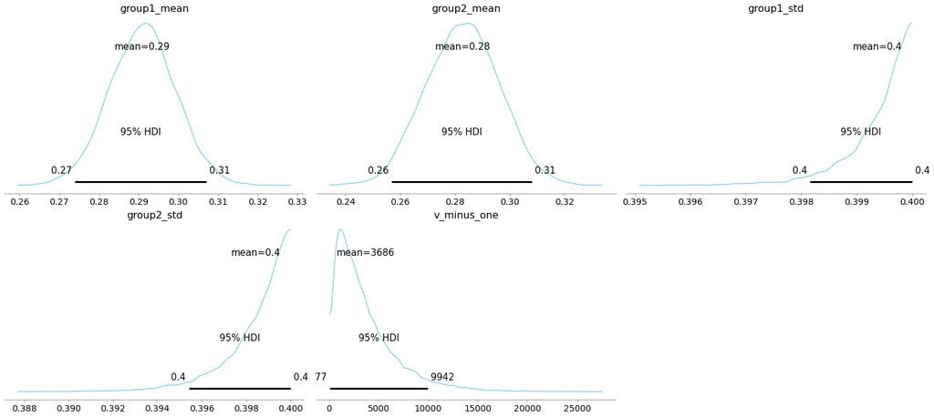

```python
# The first step of visualization comes with using the plot_posterior function.
# It takes the trace object and show the posterior mean, standard deviation and degree of freedom of the model
pm.plot_posterior(
    trace,
    var_names=["group1_mean", "group2_mean", "group1_std", "group2_std", "v_minus_one"],
    color="#87ceeb",
    hdi_prob = 0.95
)
```

```
array([<AxesSubplot:title={'center':'difference of means'}>,
       <AxesSubplot:title={'center':'difference of stds'}>,
       <AxesSubplot:title={'center':'effect size'}>], dtype=object)
```

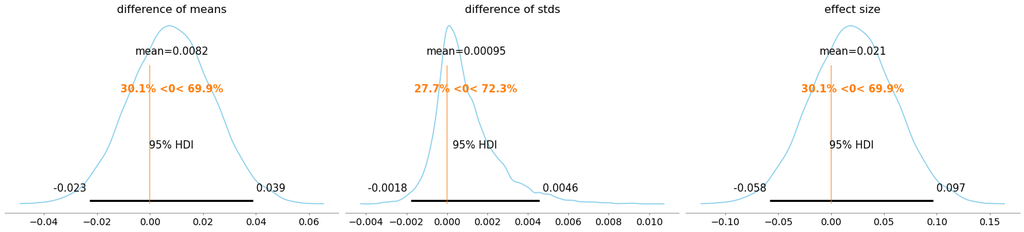

```python
# We move on to plot the posterior distribution of the difference in means, standard deviation and effect size of the two groups
pm.plot_posterior(trace,
                  var_names = ["difference of means", "difference of stds", "effect size"],
                  ref_val = 0,
                  color = "#87ceeb",
                 hdi_prob = 0.95)

# very small effect size - 2 groups do not have provide substantial evidence that their batting averages are different
# from each other.
# In general, if the percent goes down to 2.5% and go up to 97.5% (indicates 95% HDI)
```

```
array([<AxesSubplot:title={'center':'95.0% HDI'}>], dtype=object)
```

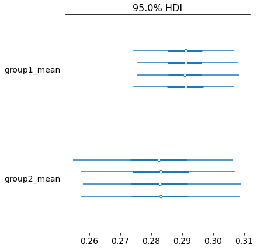

```python
# Now we make a forest plot to see how much mean does the two groups differ
pm.forestplot(trace,
          var_names = ["group1_mean", "group2_mean"],
             hdi_prob = 0.95)
```

```
array([<AxesSubplot:title={'center':'95.0% HDI'}>], dtype=object)
```

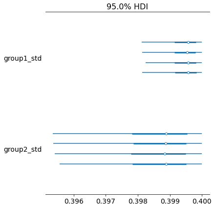

```python
# We also want to see how much spread difference occurred between the two groups by comparing standard deviation
pm.forestplot(trace,
          var_names = ["group1_std", "group2_std"],
             hdi_prob = 0.95)
```

```python
# Finally we look at the parameters in table-like view using az.summary
az.summary(trace)
```

|  | mean | sd | hdi_3% | hdi_97% | mcse_mean | mcse_sd | ess_bulk | ess_tail | r_hat |
| --- | --- | --- | --- | --- | --- | --- | --- | --- | --- |
| group1_mean | 0.291 | 0.008 | 0.275 | 0.307 | 0.000 | 0.000 | 10305.0 | 8354.0 | 1.0 |
| group2_mean | 0.283 | 0.013 | 0.258 | 0.307 | 0.000 | 0.000 | 10232.0 | 8259.0 | 1.0 |
| group1_std | 0.399 | 0.001 | 0.398 | 0.400 | 0.000 | 0.000 | 8704.0 | 5718.0 | 1.0 |
| group2_std | 0.398 | 0.001 | 0.396 | 0.400 | 0.000 | 0.000 | 7482.0 | 4518.0 | 1.0 |
| v_minus_one | 3685.731 | 3134.258 | 100.158 | 9383.717 | 31.059 | 22.546 | 8426.0 | 6636.0 | 1.0 |
| difference of means | 0.008 | 0.016 | -0.021 | 0.038 | 0.000 | 0.000 | 10142.0 | 8037.0 | 1.0 |
| difference of stds | 0.001 | 0.002 | -0.002 | 0.004 | 0.000 | 0.000 | 10521.0 | 9373.0 | 1.0 |
| effect size | 0.021 | 0.040 | -0.054 | 0.095 | 0.000 | 0.000 | 10136.0 | 7981.0 | 1.0 |

Alright! In this lecture we've discussed how to use Python to visualize credible intervals in a Bayesian t-test to effectively communicate the posterior distribution, our new belief to the audience. We emphasized the importance of visualizing the highest density interval since we can then bog down the complexity in communicating the parameters in BEST given its clear graphical representation of the posterior interval for the difference of means of two comparable groups, difference of standard deviations, and the effect size that tells us statistically how strong the difference by two groups. The highest density interval is applied so that we capture in our case study, the 95% posterior density with the shortest interval, best representing the central tendency of the posterior distribution. Bye for now!

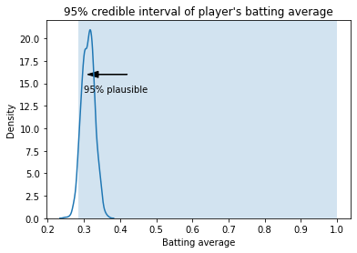

```python
# Appendix A: Draw 95% Posterior Credible Interval in seaborn

ax = sns.kdeplot(mid_batting_average)
# Let's add the title, the x label
ax.set(title = "95% credible interval of player's batting average", xlabel = "Batting average")
# and colors the entire vertical axis according to the 95% credible interval using the axvspan function.

upper_bound = stats.beta(90 + 130, 240 + 245).ppf(1)
lower_bound = stats.beta(90 + 130, 240 + 245).ppf(0.05)

ax.axvspan(lower_bound, upper_bound, alpha = 0.2)

ax.arrow(x = 0.42,                #x start point
         y = 16,                  #y start point
         dx = -0.08,              #change in x
         dy = 0,                  #change in y
         head_width=0.7,          #arrow head width
         head_length=0.03,        #arrow head length
         width=0.005,             #arrow stem width
         fc='black',              #arrow fill color
         ec='black')              #arrow edge color
# Cool! We can finally add "95% plausible" as the text at somewhere right below the arrow using the
# annotation function.
ax.annotate('95% plausible', xy=(0.3, 14))
```